# The Silent Epidemic: HIV Among the World’s Children

## 3 🗺️ Global Overview — World Map

**🗺️ World Map Chart**

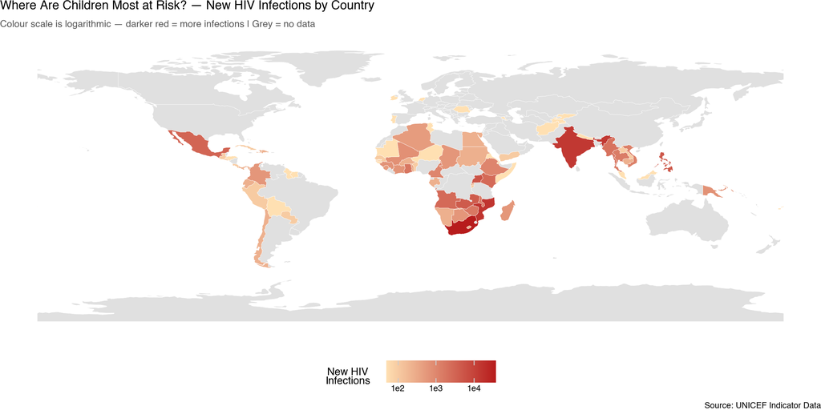

Figure 1: Estimated new HIV infections per country, most recent year available. Grey = no data.

```python
# ── Download world shapefile (bypasses macOS SSL issue) ───────────
# A shapefile contains the geographic boundaries of every country
# We download it from GitHub and save it locally so we only need internet once
GEOJSON = "countries.geojson"
URL = "https://raw.githubusercontent.com/nvkelso/natural-earth-vector/master/geojson/ne_110m_admin_0_countries.geojson"

if not os.path.exists(GEOJSON):
    # This bypasses the SSL certificate issue on older macOS versions
    ssl._create_default_https_context = ssl._create_unverified_context
    urllib.request.urlretrieve(URL, GEOJSON)
    print("Downloaded shapefile ✅")

# Load the shapefile into a GeoDataFrame (like a DataFrame but with geometry)
world_gdf = gpd.read_file(GEOJSON)
# Rename columns to match what we need
world_gdf = world_gdf.rename(columns={"ADMIN": "name", "ADM0_A3": "iso_a3"})

# ── Fix country name mismatches between UNICEF and shapefile ──────
# UNICEF uses different names than the shapefile for some countries
name_fixes = {
    "Tanzania, United Republic of": "Tanzania",
    "Democratic Republic of the Congo": "Dem. Rep. Congo",
    "Central African Republic": "Central African Rep.",
    "South Sudan": "S. Sudan",
    "Eswatini": "eSwatini",
    "Côte d'Ivoire": "Ivory Coast",
    "Congo": "Congo",
    "Lao People's Democratic Republic": "Laos",
    "Viet Nam": "Vietnam",
    "Bolivia (Plurinational State of)": "Bolivia",
    "Venezuela (Bolivarian Republic of)": "Venezuela",
}
ind1_latest["map_country"] = ind1_latest["country"].replace(name_fixes)

# ── Merge: attach HIV data onto the world map ─────────────────────
# Left join keeps ALL countries in the map — unmatched ones show grey
world_merged = world_gdf.merge(
    ind1_latest[["map_country", "obs_value"]],
    left_on="name",
    right_on="map_country",
    how="left"
)

# ── Plot ──────────────────────────────────────────────────────────
(
    ggplot(world_merged)
    + geom_map(aes(fill="obs_value"), color="white", size=0.15)
    + scale_fill_gradient(
        low="#ffe0b2", high="#b71c1c",
        na_value="#e0e0e0",
        name="New HIV\nInfections",
        trans="log10",   # log scale because values range from <50 to 39,000
    )
    + theme_void()
    + theme(
        legend_position="bottom",
        plot_title=element_text(size=13, weight="bold"),
        plot_subtitle=element_text(size=10, color="#555555"),
        figure_size=(12, 6),
    )
    + labs(
        title="Where Are Children Most at Risk? — New HIV Infections by Country",
        subtitle="Colour scale is logarithmic — darker red = more infections | Grey = no data",
        caption="Source: UNICEF Indicator Data",
    )
)
```

## 4 📊 The Hardest Hit Countries — Bar Chart

Looking at individual countries, the concentration of the epidemic becomes even clearer. The 15 countries below collectively account for the vast majority of all new HIV infections recorded in UNICEF data.

**📊 Bar Chart**

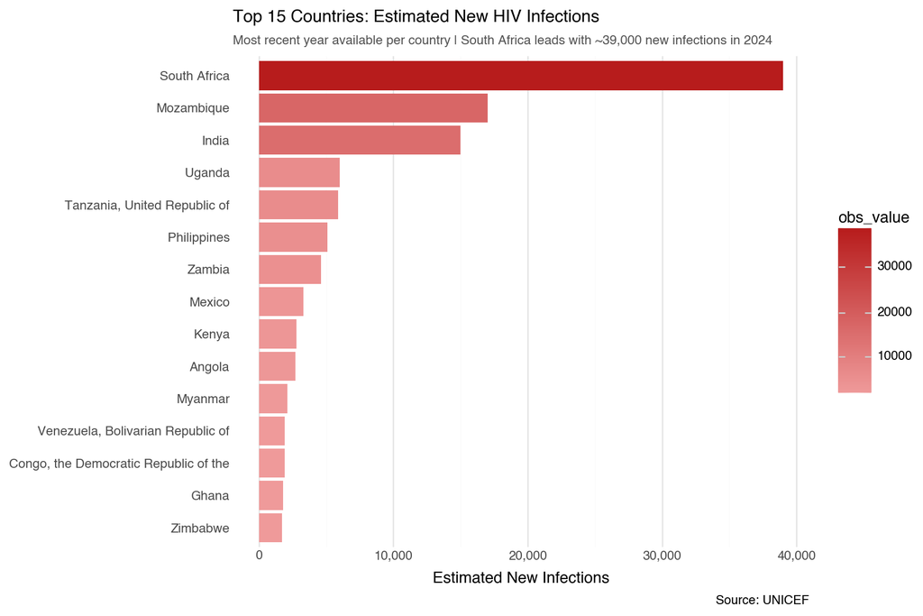

Figure 2: Top 15 countries by estimated new HIV infections (most recent year available).

```python
# ── Get top 15 countries ──────────────────────────────────────────
# nlargest(15, "obs_value") picks the 15 rows with the highest obs_value
# sort_values ascending=True so the longest bar appears at the top after coord_flip
top15 = (
    ind1_latest
    .dropna(subset=["obs_value"])
    .nlargest(15, "obs_value")
    .sort_values("obs_value", ascending=True)
)

(
    ggplot(top15, aes(x="reorder(country, obs_value)", y="obs_value", fill="obs_value"))
    + geom_col()
    + coord_flip()   # flips x and y so bars go horizontal — easier to read country names
    + scale_fill_gradient(low="#ef9a9a", high="#b71c1c")
    + scale_y_continuous(labels=lambda l: [f"{int(v):,}" for v in l])
    + theme_minimal()
    + theme(
        axis_text_y=element_text(size=9),
        plot_title=element_text(weight="bold", size=12),
        plot_subtitle=element_text(size=9, color="#555555"),
        panel_grid_major_y=element_blank(),
        figure_size=(9, 6),
    )
    + labs(
        title="Top 15 Countries: Estimated New HIV Infections",
        subtitle="Most recent year available per country | South Africa leads with ~39,000 new infections in 2024",
        x="",
        y="Estimated New Infections",
        caption="Source: UNICEF",
    )
)
```

**South Africa** stands in a category of its own with nearly 39,000 new infections in 2024 — more than double that of second-placed Mozambique (17,000). India’s appearance in third place is a reminder that the epidemic is not purely an African story. All 15 countries on this list share common risk factors: limited healthcare infrastructure, high poverty rates, and — in many cases — ongoing humanitarian crises.